[O’Hara on GitHub](https://github.com/oharac)

# Compare impacts and trends to WGI a: set up WGI data

Compiled on Sat May 2 13:07:36 2020 by ohara

```r
library(sf)
library(WDI) # install.packages('WDI')
source('https://raw.githubusercontent.com/oharac/src/master/R/common.R')

source(here('common_fxns.R'))

reload <- FALSE
```

# 1 Summary

This script downloads WGI data and prepares it in the same manner as used for the Ocean Health Index, then compares the country-level values across indicators to impacts and impact trends on threatened biodiversity.

The WGI indicator preparation is largely adapted from [this script](https://github.com/OHI-Science/ohiprep/blob/master/globalprep/prs_res_wgi/v2017/WGI_dataprep.Rmd)

# 2 Methods

## 2.1 Prepare WGI indicators

**Reference**: http://info.worldbank.org/governance/wgi/index.aspx#home

The Worldwide Governance Indicators (WGI) project reports aggregate and individual governance indicators for 215 economies over the period 1996–2015, for six dimensions of governance:

- Voice and Accountability
- Political Stability and Absence of Violence
- Government Effectiveness
- Regulatory Quality
- Rule of Law
- Control of Corruption

Access each of the 6 WGI indicators using the `WDI` package. The `series` matrix describes a huge range of variables from different databases. We will use the indicators from the World Governance Indicators database.

For each indicator, data are available for estimate, number of sources, standard error, percentile rank, and upper- and lower-bound of 90% confidence interval for percentile rank. We will focus on the estimate.

### 2.1.1 Access the data

| indicator | name | description |
| --- | --- | --- |
| CC.EST | Control of Corruption: Estimate | Control of Corruption captures perceptions of the extent to which public power is exercised for private gain, including both petty and grand forms of corruption, as well as "“capture”" of the state by… |
| VA.EST | Voice and Accountability: Estimate | Voice and Accountability captures perceptions of the extent to which a country’s citizens are able to participate in selecting their government, as well as freedom of expression, freedom of associatio… |
| GE.EST | Government Effectiveness: Estimate | Government Effectiveness captures perceptions of the quality of public services, the quality of the civil service and the degree of its independence from political pressures, the quality of policy for… |
| RQ.EST | Regulatory Quality: Estimate | Regulatory Quality captures perceptions of the ability of the government to formulate and implement sound policies and regulations that permit and promote private sector development. |
| RL.EST | Rule of Law: Estimate | Rule of Law captures perceptions of the extent to which agents have confidence in and abide by the rules of society, and in particular the quality of contract enforcement, property rights, the police,… |
| PV.EST | Political Stability and Absence of Violence/Terrorism: Estimate | Political Stability and Absence of Violence/Terrorism captures perceptions of the likelihood that the government will be destabilized or overthrown by unconstitutional or violent means, including poli… |

Pull data for each of the WGI variables and bind into a dataframe. Using long format.

### 2.1.2 Gap filling level 1: fill NA country/indicator/year/ combos

There are six WGI indicators. Our goal is to have all six indicators for all years for all countries. Some countries are lacking data for some indicators in some years. If data not available for a year/country/indicator combination, give mean of country/indicator value over rest of time span.

For each country/year/indicator combination:

- Filter to years 2003:2013.
  - Because our study covers 2003-2013, we will drop WGI observations outside this range.
  - This will affect gapfilling calculations, as values outside this range will not be included in indicator means for this step.
- identify the number of NAs.
  - an observation is available for all combinations, even if NA, so no `complete()` is necessary.
- calculate the mean value for each country/indicator across all years, dropping NAs.
- For NA observations where it is possible to calculate a mean, use that mean to replace NAs.

### 2.1.3 Calculate overall WGI score for each country in the dataset

Overall WGI score will be calculated as the mean of the available indicators (6 for most countries, minimum of 4). WGI scores are organized around a normal distribution, $\sim N(\mu = 0, \sigma = 1)$

#### 2.1.3.1 Exploring distributions of the six indicators

Unlike OHI, here we will keep the WGI mean scores on their original scale. For those familiar with WGI, it may be easier to interpret this.

Let’s check independence of the various variables.

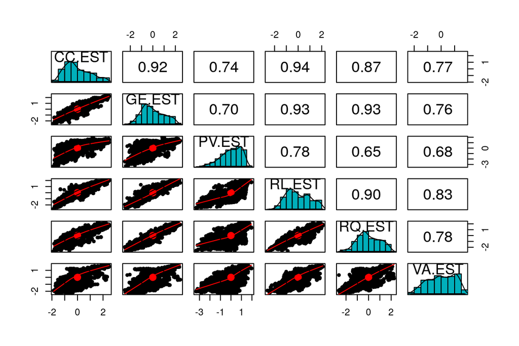

### 2.1.4 Convert country names to ohi regions

This code relies on the `name_2_rgn` function from `ohicore` package.

```
##
## These data were removed for not having any match in the lookup tables:
##
##        Eswatini North Macedonia
##               1               1
##
## These data were removed for not being of the proper rgn_type (eez,ohi_region) or mismatching region names in the lookup tables:
##                           tmp_type
## tmp_name                   disputed landlocked
##   Afghanistan                     0         11
##   Andorra                         0         11
##   Armenia                         0         11
##   Austria                         0         11
##   Belarus                         0         11
##   Bhutan                          0         11
##   Bolivia                         0         11
##   Botswana                        0         11
##   Burkina Faso                    0         11
##   Burundi                         0         11
##   Central African Republic        0         11
##   Chad                            0         11
##   Czech Republic                  0         11
##   Ethiopia                        0         11
##   Hungary                         0         11
##   Kazakhstan                      0         11
##   Kosovo                          0         11
##   Kyrgyz Republic                 0         11
##   Lao PDR                         0         11
##   Lesotho                         0         11
##   Liechtenstein                   0         11
##   Luxembourg                      0         11
##   Malawi                          0         11
##   Mali                            0         11
##   Moldova                         0         11
##   Mongolia                        0         11
##   Nepal                           0         11
##   Niger                           0         11
##   Paraguay                        0         11
##   Rwanda                          0         11
##   Serbia                          0         11
##   Slovak Republic                 0         11
##   South Sudan                     0         11
##   Switzerland                     0         11
##   Tajikistan                      0         11
##   Turkmenistan                    0         11
##   Uganda                          0         11
##   Uzbekistan                      0         11
##   West Bank and Gaza             11          0
##   Zambia                          0         11
##   Zimbabwe                        0         11
## # A tibble: 5 x 1
##   country
##   <chr>
## 1 China
## 2 Hong Kong SAR, China
## 3 Macao SAR, China
## 4 Puerto Rico
## 5 Virgin Islands (U.S.)
```

```
##      rgn_id           year          score          gapfill_within_rgn
##  Min.   :  6.0   Min.   :2003   Min.   :-2.67113   Min.   :0.000
##  1st Qu.: 65.0   1st Qu.:2005   1st Qu.:-0.62044   1st Qu.:0.000
##  Median :125.5   Median :2008   Median : 0.06017   Median :0.000
##  Mean   :124.5   Mean   :2008   Mean   : 0.10610   Mean   :0.152
##  3rd Qu.:186.0   3rd Qu.:2011   3rd Qu.: 0.87237   3rd Qu.:0.000
##  Max.   :250.0   Max.   :2013   Max.   : 2.14811   Max.   :6.000
```

### 2.1.5 Gapfill missing data (part 2)

This gapfilling occurs when we use assign a territorial region the value of their parent country. This also relies on code from `ohicore`.

Note in the wgi calcs from the ohi-science/globalprep repo, it states:

> These regions will receive an NA for their score (when established population is < 100 people). We decided it would be better to give uninhabited regions the scores of their administrative countries.

The `NA` code is commented out, however, so it appears that the scores are left unmodified.

## 2.2 Compare impact and trend to WGI indicators

### 2.2.1 Load impact and trend values

Calculated in script 6.

Let’s look at impact percent and trend, by WGI score.

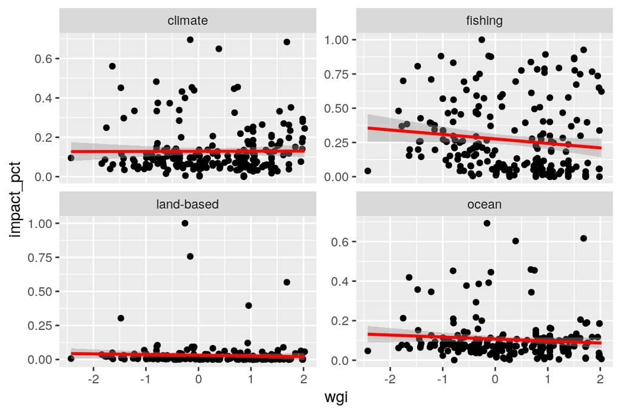

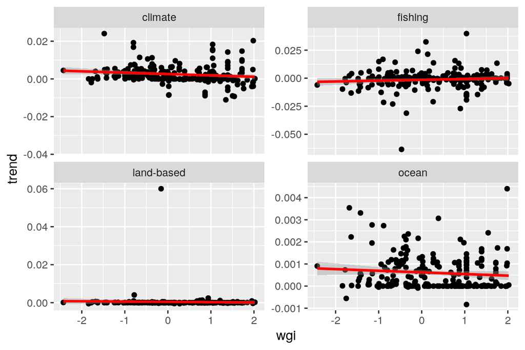

OK, maybe a slight signal here and there: impacts from fishing lower in high WGI countries?